# PML Coursera Project

Ronald Bjork

Sunday, September 21, 2014

### Background (from Coursera “Prediction Assignment Writeup” webpage):

Using devices such as Jawbone Up, Nike FuelBand, and Fitbit it is now possible to collect a large amount of data about personal activity relatively inexpensively. These type of devices are part of the quantified self movement - a group of enthusiasts who take measurements about themselves regularly to improve their health, to find patterns in their behavior, or because they are tech geeks. One thing that people regularly do is quantify how much of a particular activity they do, but they rarely quantify how well they do it. In this project, your goal will be to use data from accelerometers on the belt, forearm, arm, and dumbell of 6 participants. They were asked to perform barbell lifts correctly and incorrectly in 5 different ways. More information is available from the website here: http://groupware.les.inf.puc-rio.br/har (see the section on the Weight Lifting Exercise Dataset).

Goal (from Coursera “Prediction Assignment Writeup” webpage): The goal of your project is to predict the manner in which they did the exercise. This is the “classe” variable in the training set. You may use any of the other variables to predict with. You should create a report describing how you built your model, how you used cross validation, what you think the expected out of sample error is, and why you made the choices you did. You will also use your prediction model to predict 20 different test cases.

### Load Data:

```r
library(caret)
trainfile <- "pml-training.csv";
data <- read.csv(trainfile,stringsAsFactors=TRUE)
str(data)
```

```
## 'data.frame':    19622 obs. of  160 variables:
##  $ X                       : int  1 2 3 4 5 6 7 8 9 10 ...
##  $ user_name               : Factor w/ 6 levels "adelmo","carlitos",..: 2 2 2 2 2 2 2 2 2 2 ...
##  $ raw_timestamp_part_1    : int  1323084231 1323084231 1323084231 1323084232 1323084232 1323084232 1323084232 1323084232 1323084232 1323084232 ...
##  $ raw_timestamp_part_2    : int  788290 808298 820366 120339 196328 304277 368296 440390 484323 484434 ...
##  $ cvtd_timestamp          : Factor w/ 20 levels "02/12/2011 13:32",..: 9 9 9 9 9 9 9 9 9 9 ...
##  $ new_window              : Factor w/ 2 levels "no","yes": 1 1 1 1 1 1 1 1 1 1 ...
##  $ num_window              : int  11 11 11 12 12 12 12 12 12 12 ...
##  $ roll_belt               : num  1.41 1.41 1.42 1.48 1.48 1.45 1.42 1.42 1.43 1.45 ...
##  $ pitch_belt              : num  8.07 8.07 8.07 8.05 8.07 8.06 8.09 8.13 8.16 8.17 ...
##  $ yaw_belt                : num  -94.4 -94.4 -94.4 -94.4 -94.4 -94.4 -94.4 -94.4 -94.4 -94.4 ...
##  $ total_accel_belt        : int  3 3 3 3 3 3 3 3 3 3 ...
##  $ kurtosis_roll_belt      : Factor w/ 397 levels "","-0.016850",..: 1 1 1 1 1 1 1 1 1 1 ...
##  $ kurtosis_picth_belt     : Factor w/ 317 levels "","-0.021887",..: 1 1 1 1 1 1 1 1 1 1 ...
##  $ kurtosis_yaw_belt       : Factor w/ 2 levels "","#DIV/0!": 1 1 1 1 1 1 1 1 1 1 ...
```

[output cut: 86 more lines]

Examining the data it can be seen that many of the features(columns in table) have predominately “NA” and a few “#DIV/0”. These are generally features that are generated from other features through statistical computations. These can be called summarial statistics that include minumins, maximums, averages, variances, means, skewneww and kurtosis of sets of data. These are computed from the other recorded feature data over chunks of time during a particular activity, “classe”. The number of computations are roughly around 400. Because we are working with about 160 features total there is a danger of overfitting. So if these were choosen we might not be very successful. Some thought was to replicate these values to fill all 19800 rows but this was not done since there was sufficient features other than these summarial stats. The features(columns) that we used finally was the numeric quantities,“x y and z” components, pertaining to pitch, roll, yaw, as well as acceleration, gyros measurements, totals,and magnetudes. This is a total of 52 features they were extracted as follows:

```r
colindexes <- grep("^(roll_|pitch_|yaw_|magnet_|total_|gyros_|accel_)",names(data))
useableFeatureData <- data[,colindexes]
useableFeatureData$classe <- data$classe
```

### Partitioning the data into Training, Crossvalidation and final test for out of sample error estimate.

```r
indexes <- createDataPartition(useableFeatureData$classe, p=.80,list=FALSE)
trainAndCrossValidateData <- useableFeatureData[indexes,]
# Use only once
testData <- useableFeatureData[-indexes,]

crossIndexs <- createDataPartition(trainAndCrossValidateData$classe, p=.25,list=FALSE)
trainData <- trainAndCrossValidateData[-crossIndexs,]
crossData <- trainAndCrossValidateData[crossIndexs,]
```

### Exploratory Analysis:

```r
# Look at number of samples in each classe group
table(trainData$classe)
```

```
##
##    A    B    C    D    E
## 3348 2278 2053 1929 2164
```

```r
class(trainData$classe)
```

```
## [1] "factor"
```

Fortunatly all classe’s outcomes have sufficient numbers for fitting. Now we look a coorelations:

```r
trainData$clsnumeric <- as.numeric(trainData$classe)
indexClasse <- grep("classe",names(trainData))
M <- abs(cor(trainData[,-indexClasse]))
trainData <- trainData[,-grep("clsnumeric",names(trainData))]
diag(M) <- 0
m <- which(M > 0.80, arr.ind=T )
m
```

```
##                  row col
## yaw_belt           3   1
## total_accel_belt   4   1
## accel_belt_y       9   1
## accel_belt_z      10   1
## accel_belt_x       8   2
## magnet_belt_x     11   2
## roll_belt          1   3
## roll_belt          1   4
## accel_belt_y       9   4
## accel_belt_z      10   4
## pitch_belt         2   8
## magnet_belt_x     11   8
## roll_belt          1   9
## total_accel_belt   4   9
## accel_belt_z      10   9
## roll_belt          1  10
## total_accel_belt   4  10
## accel_belt_y       9  10
## pitch_belt         2  11
## accel_belt_x       8  11
## magnet_belt_z     13  12
## magnet_belt_y     12  13
## gyros_arm_y       19  18
## gyros_arm_x       18  19
## magnet_arm_x      24  21
## accel_arm_x       21  24
## magnet_arm_z      26  25
## magnet_arm_y      25  26
## accel_dumbbell_x  34  28
## accel_dumbbell_z  36  29
## gyros_dumbbell_z  33  31
## gyros_forearm_z   46  31
## gyros_dumbbell_x  31  33
## gyros_forearm_z   46  33
## pitch_dumbbell    28  34
## yaw_dumbbell      29  36
## gyros_forearm_z   46  45
## gyros_dumbbell_x  31  46
## gyros_dumbbell_z  33  46
## gyros_forearm_y   45  46
```

Correlations with classe(used clsnumeric)

```r
M[53,-53]
```

```
##            roll_belt           pitch_belt             yaw_belt
##            0.0635536            0.0174113            0.0091761
##     total_accel_belt         gyros_belt_x         gyros_belt_y
##            0.0785723            0.0142928            0.0181145
##         gyros_belt_z         accel_belt_x         accel_belt_y
##            0.0133336            0.0007835            0.0034413
##         accel_belt_z        magnet_belt_x        magnet_belt_y
##            0.0795077            0.0110032            0.2846263
##        magnet_belt_z             roll_arm            pitch_arm
##            0.1829524            0.0784456            0.1798246
##              yaw_arm      total_accel_arm          gyros_arm_x
##            0.0416538            0.1227078            0.0142730
##          gyros_arm_y          gyros_arm_z          accel_arm_x
##            0.0268949            0.0032814            0.2497532
##          accel_arm_y          accel_arm_z         magnet_arm_x
##            0.0875801            0.0462182            0.2999544
##         magnet_arm_y         magnet_arm_z        roll_dumbbell
##            0.2554332            0.1515225            0.0416008
##       pitch_dumbbell         yaw_dumbbell total_accel_dumbbell
##            0.0856278            0.0058183            0.0540012
##     gyros_dumbbell_x     gyros_dumbbell_y     gyros_dumbbell_z
##            0.0094048            0.0347947            0.0086841
##     accel_dumbbell_x     accel_dumbbell_y     accel_dumbbell_z
##            0.1194196            0.0158615            0.0711288
##    magnet_dumbbell_x    magnet_dumbbell_y    magnet_dumbbell_z
##            0.0698442            0.0014401            0.1411818
##         roll_forearm        pitch_forearm          yaw_forearm
##            0.0256567            0.3531335            0.0504645
##  total_accel_forearm      gyros_forearm_x      gyros_forearm_y
##            0.1528174            0.0256956            0.0103971
##      gyros_forearm_z      accel_forearm_x      accel_forearm_y
##            0.0112187            0.1914401            0.0313712
##      accel_forearm_z     magnet_forearm_x     magnet_forearm_y
##            0.0071909            0.1842044            0.1092855
##     magnet_forearm_z
##            0.0429902
```

```r
max(M[53,-53])
```

```
## [1] 0.3531
```

As can be seen above, no single feature is strongly correlated with ‘classe’. The most correlation is 34% with ‘pitch_forearm’.

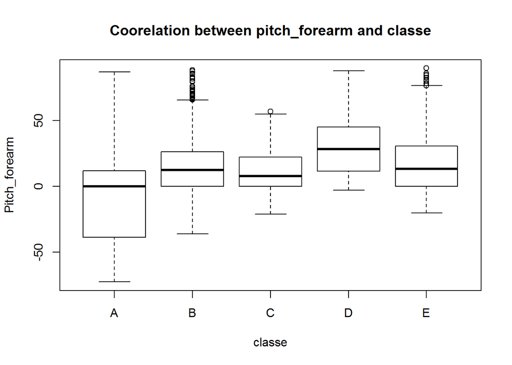

```r
  indexpitchforearm <- grep("pitch_forearm",trainData)
  plot(trainData$classe,trainData$pitch_forearm,ylab="Pitch_forearm",xlab="classe",main="Coorelation between pitch_forearm and classe")
```

Standardization:

```r
# Standardizing
standardize <- function(d,sdv,mn){
    if(is.na(d) | is.na(sdv) | sdv == 0){
      d <- mn
    }else{
      d <- as.numeric(d) # in case it isn't, but probably not needed
      d <- (d - mn)/sdv
    }
}

colsThatFailed <- c()
indexclasse <- grep("classe",names(trainData))
trainData_stdz <- trainData[,-indexclasse];
colnumber <- length(colnames(trainData_stdz))
badCol <- FALSE
for(col in 1:colnumber){
  #print(col)
  coldata <- trainData_stdz[,col]
  if(is.factor(coldata)){
    coldata <- as.numeric(coldata)
  }
  sdv <- sd(coldata,na.rm=TRUE)
  mn <- mean(coldata,na.rm=TRUE)
  if(!is.na(mn)){
    trainData_stdz[,col] <- sapply(trainData_stdz[,col],standardize,sdv,mn)
  }else{
    print(paste("failed to get mean for col", col))
    colsThatFailed <- c(colsThatFailed,col)
    badCol = TRUE
  }
}
if(badCol){
  trainData_stdz <- trainData_stdz[,-colsThatFailed]
}
trainData_stdz$classe <- trainData$classe
```

### Features examinations for possible compression of data:

```r
M <- abs(cor(trainData_stdz[,-grep("classe",names(trainData_stdz))]))
diag(M) <- 0
m <- which(M > 0.95, arr.ind=T )
m
```

```
##                  row col
## total_accel_belt   4   1
## accel_belt_z      10   1
## accel_belt_x       8   2
## roll_belt          1   4
## accel_belt_z      10   4
## pitch_belt         2   8
## roll_belt          1  10
## total_accel_belt   4  10
## gyros_dumbbell_z  33  31
## gyros_dumbbell_x  31  33
## gyros_forearm_z   46  33
## gyros_dumbbell_z  33  46
```

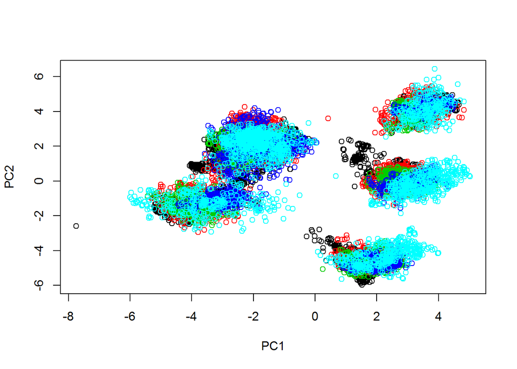

```r
indexOfclasse <- which(names(trainData_stdz) == "classe")
dataforpc <- trainData_stdz[,-indexOfclasse]
prComp <- prcomp(dataforpc)
classeType <- trainData_stdz$classe

plot(prComp$x[,1],prComp$x[,2],col=classeType,xlab="PC1",ylab="PC2")
```

Notice the grouping but still there is no seperation ; 2 components far too few.

```r
summary(prComp)
```

```
## Importance of components:
##                          PC1   PC2    PC3    PC4    PC5    PC6    PC7
## Standard deviation     2.889 2.844 2.1670 2.1011 1.9182 1.7283 1.4884
## Proportion of Variance 0.161 0.156 0.0903 0.0849 0.0708 0.0574 0.0426
## Cumulative Proportion  0.161 0.316 0.4063 0.4913 0.5620 0.6194 0.6621
##                           PC8   PC9   PC10   PC11   PC12  PC13  PC14
## Standard deviation     1.4383 1.310 1.2321 1.1766 1.0626 0.993 0.940
## Proportion of Variance 0.0398 0.033 0.0292 0.0266 0.0217 0.019 0.017
## Cumulative Proportion  0.7018 0.735 0.7640 0.7906 0.8124 0.831 0.848
##                          PC15   PC16   PC17   PC18    PC19    PC20    PC21
## Standard deviation     0.9048 0.8807 0.8242 0.7390 0.71786 0.69349 0.63749
## Proportion of Variance 0.0157 0.0149 0.0131 0.0105 0.00991 0.00925 0.00782
## Cumulative Proportion  0.8640 0.8790 0.8920 0.9025 0.91244 0.92169 0.92950
##                           PC22    PC23    PC24    PC25    PC26    PC27
## Standard deviation     0.63136 0.59591 0.57317 0.55106 0.53895 0.50630
## Proportion of Variance 0.00767 0.00683 0.00632 0.00584 0.00559 0.00493
## Cumulative Proportion  0.93717 0.94400 0.95032 0.95615 0.96174 0.96667
##                           PC28    PC29    PC30    PC31    PC32    PC33
## Standard deviation     0.48094 0.44400 0.40038 0.37585 0.36243 0.34445
## Proportion of Variance 0.00445 0.00379 0.00308 0.00272 0.00253 0.00228
## Cumulative Proportion  0.97112 0.97491 0.97799 0.98071 0.98324 0.98552
##                           PC34    PC35    PC36    PC37    PC38    PC39
## Standard deviation     0.33547 0.30312 0.28056 0.25459 0.23768 0.23439
## Proportion of Variance 0.00216 0.00177 0.00151 0.00125 0.00109 0.00106
## Cumulative Proportion  0.98768 0.98945 0.99096 0.99221 0.99329 0.99435
##                           PC40    PC41    PC42    PC43    PC44    PC45
## Standard deviation     0.20055 0.19423 0.18442 0.18009 0.17075 0.16218
## Proportion of Variance 0.00077 0.00073 0.00065 0.00062 0.00056 0.00051
## Cumulative Proportion  0.99512 0.99585 0.99650 0.99713 0.99769 0.99819
##                           PC46    PC47    PC48    PC49    PC50    PC51
## Standard deviation     0.15582 0.14698 0.13913 0.11266 0.08926 0.07655
## Proportion of Variance 0.00047 0.00042 0.00037 0.00024 0.00015 0.00011
## Cumulative Proportion  0.99866 0.99908 0.99945 0.99969 0.99985 0.99996
##                           PC52
## Standard deviation     0.04624
## Proportion of Variance 0.00004
## Cumulative Proportion  1.00000
```

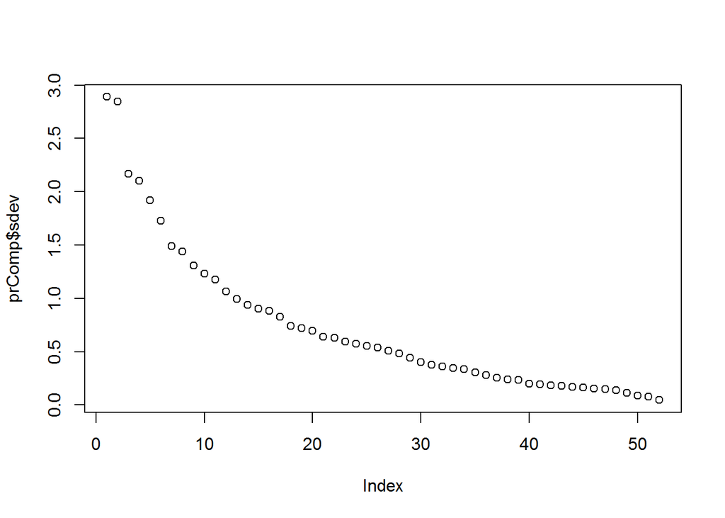

```r
plot(prComp$sdev)
```

Clearly there are many PCA vectors that contribute. It isn’t clear whether using PCA to compress the number of features to fit is worthwhile. And it could reduce interpetablity of the eventual model.

## Model Selection:

Fitting a Model:

### Decision Tree

In order to resolve classe c, 5 levels was required. This is likely overfitted particularily for c

```r
treeTrainData <- trainData
set.seed(3344)
decisionTreeModel <- train(classe ~.,method="rpart",tuneLength=5,data=treeTrainData)
print(decisionTreeModel$finalModel)
```

```
## n= 11772
##
## node), split, n, loss, yval, (yprob)
##       * denotes terminal node
##
##  1) root 11772 8424 A (0.28 0.19 0.17 0.16 0.18)
##    2) roll_belt< 130.5 10788 7451 A (0.31 0.21 0.19 0.18 0.11)
##      4) pitch_forearm< -34.55 937    3 A (1 0.0032 0 0 0) *
##      5) pitch_forearm>=-34.55 9851 7448 A (0.24 0.23 0.21 0.2 0.12)
##       10) magnet_dumbbell_y< 439.5 8315 5955 A (0.28 0.18 0.24 0.19 0.11)
##         20) roll_forearm< 126.5 5247 3128 A (0.4 0.18 0.19 0.17 0.059) *
##         21) roll_forearm>=126.5 3068 2051 C (0.079 0.17 0.33 0.23 0.19)
##           42) magnet_dumbbell_y< 291.5 1783  894 C (0.099 0.11 0.5 0.15 0.14) *
##           43) magnet_dumbbell_y>=291.5 1285  835 D (0.051 0.24 0.1 0.35 0.26) *
##       11) magnet_dumbbell_y>=439.5 1536  745 B (0.028 0.51 0.039 0.23 0.19)
##         22) total_accel_dumbbell>=5.5 1087  374 B (0.04 0.66 0.054 0.024 0.23) *
##         23) total_accel_dumbbell< 5.5 449  126 D (0 0.17 0.0022 0.72 0.1) *
##    3) roll_belt>=130.5 984   11 E (0.011 0 0 0 0.99) *
```

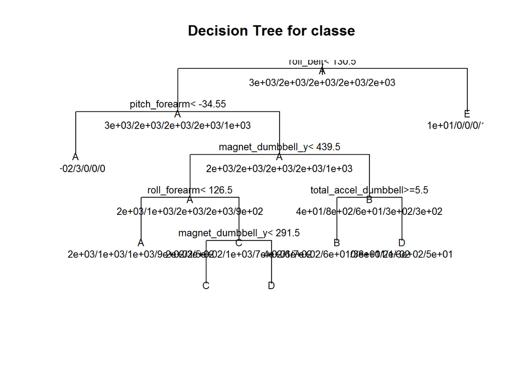

```r
plot(decisionTreeModel$finalModel,uniform=TRUE,main="Decision Tree for classe")
text(decisionTreeModel$finalModel, use.n=TRUE,all=TRUE,cex=.8)
```

Insample error calculation:

```r
indexClasse <- grep("classe",names(treeTrainData))
predictions <- predict(decisionTreeModel,newdata=treeTrainData[,-indexClasse])
cm <- confusionMatrix(predictions,treeTrainData$classe)
cm
```

```
## Confusion Matrix and Statistics
##
##           Reference
## Prediction    A    B    C    D    E
##          A 3053  973  976  871  311
##          B   43  713   59   26  246
##          C  176  204  889  259  255
##          D   65  388  129  773  379
##          E   11    0    0    0  973
##
## Overall Statistics
##
##                Accuracy : 0.544
##                  95% CI : (0.535, 0.553)
##     No Information Rate : 0.284
##     P-Value [Acc > NIR] : <2e-16
##
##                   Kappa : 0.405
##  Mcnemar's Test P-Value : <2e-16
##
## Statistics by Class:
##
##                      Class: A Class: B Class: C Class: D Class: E
## Sensitivity             0.912   0.3130   0.4330   0.4007   0.4496
## Specificity             0.628   0.9606   0.9080   0.9024   0.9989
## Pos Pred Value          0.494   0.6559   0.4986   0.4458   0.9888
## Neg Pred Value          0.947   0.8535   0.8835   0.8848   0.8896
## Prevalence              0.284   0.1935   0.1744   0.1639   0.1838
## Detection Rate          0.259   0.0606   0.0755   0.0657   0.0827
## Detection Prevalence    0.525   0.0923   0.1515   0.1473   0.0836
## Balanced Accuracy       0.770   0.6368   0.6705   0.6515   0.7242
```

In sample Accuracy 0.5437 or0.4563 error

Out of sample error via cross validation:

```r
indexClasse <- grep("classe",names(crossData))
predictions <- predict(decisionTreeModel,newdata=crossData[,-indexClasse])
cm <- confusionMatrix(predictions,crossData$classe)
cm
```

```
## Confusion Matrix and Statistics
##
##           Reference
## Prediction    A    B    C    D    E
##          A 1019  326  319  290  115
##          B   19  236   24    6   79
##          C   57   72  297   98   97
##          D   20  126   45  250  108
##          E    1    0    0    0  323
##
## Overall Statistics
##
##                Accuracy : 0.541
##                  95% CI : (0.525, 0.557)
##     No Information Rate : 0.284
##     P-Value [Acc > NIR] : <2e-16
##
##                   Kappa : 0.401
##  Mcnemar's Test P-Value : <2e-16
##
## Statistics by Class:
##
##                      Class: A Class: B Class: C Class: D Class: E
## Sensitivity             0.913   0.3105   0.4336   0.3882   0.4474
## Specificity             0.626   0.9596   0.9001   0.9089   0.9997
## Pos Pred Value          0.493   0.6484   0.4783   0.4554   0.9969
## Neg Pred Value          0.948   0.8529   0.8826   0.8834   0.8893
## Prevalence              0.284   0.1935   0.1744   0.1640   0.1839
## Detection Rate          0.259   0.0601   0.0756   0.0637   0.0823
## Detection Prevalence    0.527   0.0927   0.1581   0.1398   0.0825
## Balanced Accuracy       0.770   0.6351   0.6668   0.6486   0.7235
```

Out of sample accuracy 0.5411 or0.4589 error

### Decision Tree with PCA preprocess

```r
set.seed(3344)
decisionTreeModel <- train(classe ~.,method="rpart", preProcess="pca", tuneLength=5, data=treeTrainData)
print(decisionTreeModel$finalModel)
```

```
## n= 11772
##
## node), split, n, loss, yval, (yprob)
##       * denotes terminal node
##
## 1) root 11772 8424 A (0.28 0.19 0.17 0.16 0.18)
##   2) PC14>=-0.9473 10669 7348 A (0.31 0.19 0.19 0.17 0.14)
##     4) PC8< 1.195 8508 5457 A (0.36 0.17 0.22 0.11 0.14)
##       8) PC12>=-1.347 8018 4981 A (0.38 0.18 0.23 0.11 0.11) *
##       9) PC12< -1.347 490  165 E (0.029 0.11 0.02 0.18 0.66) *
##     5) PC8>=1.195 2161 1327 D (0.12 0.24 0.086 0.39 0.16) *
##   3) PC14< -0.9473 1103  463 E (0.024 0.24 0.029 0.13 0.58) *
```

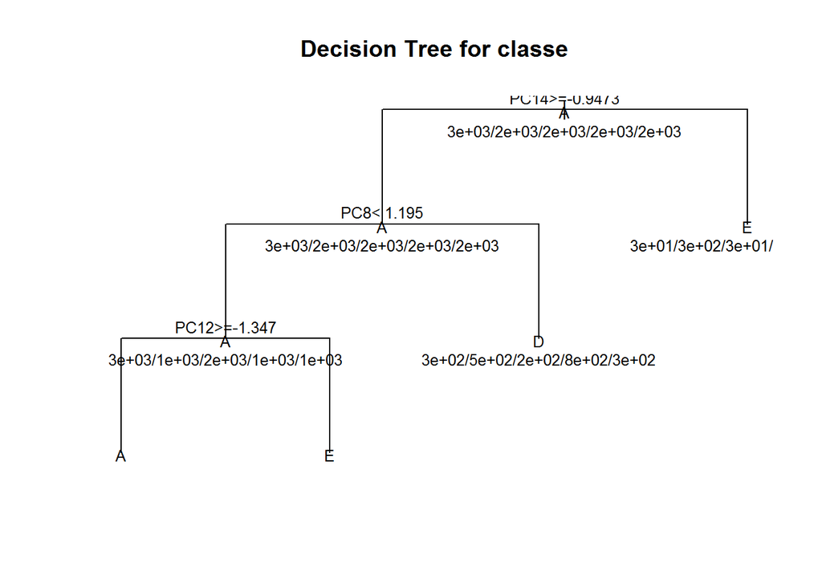

```r
plot(decisionTreeModel$finalModel,uniform=TRUE,main="Decision Tree for classe")
text(decisionTreeModel$finalModel, use.n=TRUE,all=TRUE,cex=.8)
```

```r
indexClasse <- grep("classe",names(treeTrainData))
predictions <- predict(decisionTreeModel,newdata=treeTrainData[,-indexClasse])
cm <- confusionMatrix(predictions,treeTrainData$classe)
cm
```

```
## Confusion Matrix and Statistics
##
##           Reference
## Prediction    A    B    C    D    E
##          A 3037 1432 1826  869  854
##          B    0    0    0    0    0
##          C    0    0    0    0    0
##          D  270  527  185  834  345
##          E   41  319   42  226  965
##
## Overall Statistics
##
##                Accuracy : 0.411
##                  95% CI : (0.402, 0.42)
##     No Information Rate : 0.284
##     P-Value [Acc > NIR] : <2e-16
##
##                   Kappa : 0.216
##  Mcnemar's Test P-Value : NA
##
## Statistics by Class:
##
##                      Class: A Class: B Class: C Class: D Class: E
## Sensitivity             0.907    0.000    0.000   0.4323    0.446
## Specificity             0.409    1.000    1.000   0.8652    0.935
## Pos Pred Value          0.379      NaN      NaN   0.3859    0.606
## Neg Pred Value          0.917    0.806    0.826   0.8861    0.882
## Prevalence              0.284    0.194    0.174   0.1639    0.184
## Detection Rate          0.258    0.000    0.000   0.0708    0.082
## Detection Prevalence    0.681    0.000    0.000   0.1836    0.135
## Balanced Accuracy       0.658    0.500    0.500   0.6488    0.690
```

In sample accuracy 0.4108 or 0.5892 error

```r
# In sample Accuracy of 40% 5 deep - 60% error
indexClasse <- grep("classe",names(crossData))
predictions <- predict(decisionTreeModel,newdata=crossData[,-indexClasse])
cm <- confusionMatrix(predictions,crossData$classe)
cm
```

```
## Confusion Matrix and Statistics
##
##           Reference
## Prediction    A    B    C    D    E
##          A 1014  476  607  302  285
##          B    0    0    0    0    0
##          C    0    0    0    0    0
##          D   85  163   67  244  131
##          E   17  121   11   98  306
##
## Overall Statistics
##
##                Accuracy : 0.398
##                  95% CI : (0.383, 0.414)
##     No Information Rate : 0.284
##     P-Value [Acc > NIR] : <2e-16
##
##                   Kappa : 0.199
##  Mcnemar's Test P-Value : NA
##
## Statistics by Class:
##
##                      Class: A Class: B Class: C Class: D Class: E
## Sensitivity             0.909    0.000    0.000   0.3789   0.4238
## Specificity             0.406    1.000    1.000   0.8641   0.9229
## Pos Pred Value          0.378      NaN      NaN   0.3536   0.5533
## Neg Pred Value          0.918    0.806    0.826   0.8764   0.8767
## Prevalence              0.284    0.194    0.174   0.1640   0.1839
## Detection Rate          0.258    0.000    0.000   0.0621   0.0779
## Detection Prevalence    0.683    0.000    0.000   0.1757   0.1408
## Balanced Accuracy       0.657    0.500    0.500   0.6215   0.6734
```

Out of sample accuracy 0.3983 or 0.6017 error

### Randomm Forest

```r
library(randomForest)
set.seed(3344)
#trainData_stdz <- trainData
indexClasse <- grep("classe",names(trainData))
rfModel <- randomForest(trainData[,-indexClasse],trainData[,indexClasse],ntree=50,prox=TRUE)
indexClasse <- grep("classe",names(crossData))
predictions <- predict(rfModel,crossData[,-indexClasse])
cm <- confusionMatrix(predictions,crossData$classe)
cm
```

```
## Confusion Matrix and Statistics
##
##           Reference
## Prediction    A    B    C    D    E
##          A 1113    5    0    0    0
##          B    2  752    4    0    0
##          C    1    3  678    9    1
##          D    0    0    3  635    2
##          E    0    0    0    0  719
##
## Overall Statistics
##
##                Accuracy : 0.992
##                  95% CI : (0.989, 0.995)
##     No Information Rate : 0.284
##     P-Value [Acc > NIR] : <2e-16
##
##                   Kappa : 0.99
##  Mcnemar's Test P-Value : NA
##
## Statistics by Class:
##
##                      Class: A Class: B Class: C Class: D Class: E
## Sensitivity             0.997    0.989    0.990    0.986    0.996
## Specificity             0.998    0.998    0.996    0.998    1.000
## Pos Pred Value          0.996    0.992    0.980    0.992    1.000
## Neg Pred Value          0.999    0.997    0.998    0.997    0.999
## Prevalence              0.284    0.194    0.174    0.164    0.184
## Detection Rate          0.283    0.191    0.173    0.162    0.183
## Detection Prevalence    0.285    0.193    0.176    0.163    0.183
## Balanced Accuracy       0.998    0.994    0.993    0.992    0.998
```

Out of sample accuracy 0.9924 or 0.0076 error

### Linear Discrimanate Analysis

```r
set.seed(3344)
ldaModel <- train(classe ~.,method="lda",data=trainData)
predictions <- predict(ldaModel,crossData[,-indexClasse])
cm <- confusionMatrix(predictions,crossData$classe)
cm
```

```
## Confusion Matrix and Statistics
##
##           Reference
## Prediction   A   B   C   D   E
##          A 911 105  61  33  26
##          B  20 475  73  29 118
##          C  96 104 460  88  63
##          D  84  33  76 456  72
##          E   5  43  15  38 443
##
## Overall Statistics
##
##                Accuracy : 0.699
##                  95% CI : (0.684, 0.713)
##     No Information Rate : 0.284
##     P-Value [Acc > NIR] : <2e-16
##
##                   Kappa : 0.619
##  Mcnemar's Test P-Value : <2e-16
##
## Statistics by Class:
##
##                      Class: A Class: B Class: C Class: D Class: E
## Sensitivity             0.816    0.625    0.672    0.708    0.614
## Specificity             0.920    0.924    0.892    0.919    0.968
## Pos Pred Value          0.802    0.664    0.567    0.632    0.814
## Neg Pred Value          0.927    0.911    0.928    0.941    0.918
## Prevalence              0.284    0.194    0.174    0.164    0.184
## Detection Rate          0.232    0.121    0.117    0.116    0.113
## Detection Prevalence    0.289    0.182    0.207    0.184    0.139
## Balanced Accuracy       0.868    0.775    0.782    0.814    0.791
```

Linear Discriminate Analysis gives about 0.699 % percent accuracy or 0.301 error

## Conclusion:

Clearly “Random Forest” model fits the best. Not very interpetable but that isn’t as much of a concern than is accuracy. So we go with Random forest. Now that the model has been chosen, we make the final test for out of sample error with a fresh set of data not yet used.

### Computing out of sample error:

```r
indexClasse <- grep("classe",names(testData))
predictions <- predict(rfModel,testData[,-indexClasse])
cm <- confusionMatrix(predictions,testData$classe)
cm
```

```
## Confusion Matrix and Statistics
##
##           Reference
## Prediction    A    B    C    D    E
##          A 1112    9    0    0    0
##          B    4  748    4    0    0
##          C    0    2  678    9    0
##          D    0    0    2  634    0
##          E    0    0    0    0  721
##
## Overall Statistics
##
##                Accuracy : 0.992
##                  95% CI : (0.989, 0.995)
##     No Information Rate : 0.284
##     P-Value [Acc > NIR] : <2e-16
##
##                   Kappa : 0.99
##  Mcnemar's Test P-Value : NA
##
## Statistics by Class:
##
##                      Class: A Class: B Class: C Class: D Class: E
## Sensitivity             0.996    0.986    0.991    0.986    1.000
## Specificity             0.997    0.997    0.997    0.999    1.000
## Pos Pred Value          0.992    0.989    0.984    0.997    1.000
## Neg Pred Value          0.999    0.997    0.998    0.997    1.000
## Prevalence              0.284    0.193    0.174    0.164    0.184
## Detection Rate          0.283    0.191    0.173    0.162    0.184
## Detection Prevalence    0.286    0.193    0.176    0.162    0.184
## Balanced Accuracy       0.997    0.991    0.994    0.993    1.000
```

### Or 0.0076 out of sample error

Now for estimating classe from ‘pml-testing.cv’:

```r
testfile <- "pml-testing.csv";
testdataRaw <- read.csv(testfile,stringsAsFactors=TRUE)
colindexes <- grep("^(roll_|pitch_|yaw_|magnet_|total_|gyros_|accel_)",names(testdataRaw))
testdataUse <- testdataRaw[,colindexes]
testdataUse$problem_id <- testdataRaw$problem_id
indexProbID <- grep("problem_id",names(testdataUse))
predictions <- predict(rfModel,testdataUse[,-indexProbID])
answers <- as.character(predictions)
answers
```

```
##  [1] "B" "A" "B" "A" "A" "E" "D" "B" "A" "A" "B" "C" "B" "A" "E" "E" "A"
## [18] "B" "B" "B"
```

```r
# pml_write_files = function(x){
#   n = length(x)
#   for(i in 1:n){
#     filename = paste0("problem_id_",i,".txt")
#     write.table(x[i],file=filename,quote=FALSE,row.names=FALSE,col.names=FALSE)
#   }
# }
#
#
# pml_write_files(answers)
```